# 4. Modeling PCA & K-means

## Ecommerce customer segementation

## Part IV: Modeling - PCA and K-means

## 0) Setup

### 0.a) Import packages

```python
import numpy as np
import pandas as pd
import seaborn as sns
import matplotlib.pyplot as plt
from scipy.stats import norm
import os
```

```python
from IPython.core.interactiveshell import InteractiveShell

InteractiveShell.ast_node_interactivity = "all"

import warnings
warnings.filterwarnings('ignore')
```

```python
pd.set_option("display.max_rows", 500)
pd.set_option("display.max_columns", 500)
pd.set_option("display.width", 1000)
```

### 0.b) Get Amazon IAM execution role and instance region

```python
import boto3, os, sagemaker
from sagemaker import get_execution_role
```

```python
# Define IAM role- this will be necessary when defining your model
iam_role = get_execution_role()

# set the region of the instance and get a reference to the client
my_region = boto3.Session().region_name

# sagemaker session handle
sm_session = sagemaker.session.Session(boto3.Session())

print("Success - the SageMaker instance is in the " + my_region + " region")
```

```
Success - the SageMaker instance is in the us-west-2 region
```

```python
#bucket = "radybigdata"
bucket = "finalcustomersegmentation"
prefix = "ecommerce"
```

## 1). Read aggregated file

```python
tt =  pd.read_csv("s3://{}/{}/agg_info.csv".format(bucket,prefix))
```

```python
tt.head()
```

|  | customer_unique_id | monetary | frequency | rating | payment_installments | recency | length |
| --- | --- | --- | --- | --- | --- | --- | --- |
| 0 | 0000366f3b9a7992bf8c76cfdf3221e2 | 129.90 | 1 | 5.0 | 8.0 | 115.0 | 0.0 |
| 1 | 0000b849f77a49e4a4ce2b2a4ca5be3f | 18.90 | 1 | 4.0 | 1.0 | 118.0 | 0.0 |
| 2 | 0000f46a3911fa3c0805444483337064 | 69.00 | 1 | 3.0 | 8.0 | 541.0 | 0.0 |
| 3 | 0000f6ccb0745a6a4b88665a16c9f078 | 25.99 | 1 | 4.0 | 4.0 | 325.0 | 0.0 |
| 4 | 0004aac84e0df4da2b147fca70cf8255 | 180.00 | 1 | 5.0 | 6.0 | 292.0 | 0.0 |

```python
tt.dtypes
```

```
customer_unique_id       object
monetary                float64
frequency                 int64
rating                  float64
payment_installments    float64
recency                 float64
length                  float64
dtype: object
```

```python
tt.shape
```

```
(94087, 7)
```

```python
tt.dropna(inplace = True)
```

```python
tt.shape
```

```
(94087, 7)
```

## 2). PCA Modeling to reduce dimensioning

```python
from sklearn.preprocessing import MinMaxScaler
scaler=MinMaxScaler()
```

```python
ts = tt.iloc[:,1:]
t =pd.DataFrame(scaler.fit_transform(ts))
t.columns=ts.columns
t.index=ts.index
```

```python
t.head()
```

|  | monetary | frequency | rating | payment_installments | recency | length |
| --- | --- | --- | --- | --- | --- | --- |
| 0 | 0.009603 | 0.0 | 1.00 | 0.333333 | 0.157967 | 0.0 |
| 1 | 0.001343 | 0.0 | 0.75 | 0.041667 | 0.162088 | 0.0 |
| 2 | 0.005071 | 0.0 | 0.50 | 0.333333 | 0.743132 | 0.0 |
| 3 | 0.001871 | 0.0 | 0.75 | 0.166667 | 0.446429 | 0.0 |
| 4 | 0.013330 | 0.0 | 1.00 | 0.250000 | 0.401099 | 0.0 |

```python
t.describe()
```

|  | monetary | frequency | rating | payment_installments | recency | length |
| --- | --- | --- | --- | --- | --- | --- |
| count | 94087.000000 | 94087.000000 | 94087.000000 | 94087.000000 | 94087.000000 | 94087.000000 |
| mean | 0.011070 | 0.003231 | 0.772295 | 0.121202 | 0.332284 | 0.004181 |
| std | 0.018584 | 0.011495 | 0.334217 | 0.111822 | 0.210380 | 0.039649 |
| min | 0.000000 | 0.000000 | 0.000000 | 0.000000 | 0.000000 | 0.000000 |
| 25% | 0.003575 | 0.000000 | 0.750000 | 0.041667 | 0.162088 | 0.000000 |
| 50% | 0.006626 | 0.000000 | 1.000000 | 0.083333 | 0.304945 | 0.000000 |
| 75% | 0.011835 | 0.000000 | 1.000000 | 0.166667 | 0.482143 | 0.000000 |
| max | 1.000000 | 1.000000 | 1.000000 | 1.000000 | 1.000000 | 1.000000 |

### a. Dimensionality reduction

We will be using principal component analysis (PCA) to reduce the dimensionality of our data. This method decomposes the data matrix into features that are orthogonal with each other. The resultant orthogonal features are linear combinations of the original feature set. You can think of this method as taking many features and combining similar or redundant features together to form a new, smaller feature set.

specify the bucket name for a bucket in your account where you want SageMaker model parameters to be stored

```python
from sagemaker import PCA
num_components=4

pca_SM = PCA(role=iam_role,
          train_instance_count=1,
          train_instance_type='ml.m5.xlarge',
          output_path='s3://'+ bucket +'/ecommerce/',
            num_components=num_components)
```

```python
train_data = t.values.astype('float32')
```

```python
%%time
pca_SM.fit(pca_SM.record_set(train_data))
```

[output not shown]

[output cut: 18 more lines]

### b. Accessing the PCA model attributes

Now that the training job is complete, find the job under Jobs in the Training subsection in the Amazon SageMaker console.

Model artifacts are stored in Amazon S3 after they have been trained. This is the same model artifact that is used to deploy a trained model using Amazon SageMaker. Since many of the Amazon SageMaker algorithms use MXNet for computational speed, the model artifact is stored as an ND array. For an output path that was specified during the training call, the model resides in “training job name”–> output–>model.tar.gz file, which is a TAR archive file compressed with GNU zip (gzip) compression.

```python
job_name='pca-2020-03-18-04-34-21-802'
model_key = "ecommerce/" + job_name + "/output/model.tar.gz"

boto3.resource('s3').Bucket(bucket).download_file(model_key, 'model.tar.gz')
os.system('tar -zxvf model.tar.gz')
os.system('unzip model_algo-1')
```

```
0
```

```
2304
```

After the model is unzipped and decompressed, we can load the ND array using MXNet.

```python
#!pip install mxnet
```

```python
import mxnet as mx
pca_model_params = mx.ndarray.load('model_algo-1')
```

Three groups of model parameters are contained within the PCA model.

mean: is optional and is only available if the “subtract_mean” hyperparameter is true when calling the training step from the original PCA SageMaker function.

v: contains the principal components (same as ‘components_’ in the sklearn PCA model).

s: the singular values of the components for the PCA transformation. This does not exactly give the % variance from the original feature space, but can give the % variance from the projected feature space.

explained-variance-ratio ~= square(s) / sum(square(s))

To calculate the exact explained-variance-ratio vector if needed, it simply requires saving the sum of squares of the original data (call that N) and computing explained-variance-ratio = square(s) / N.

```python
s=pd.DataFrame(pca_model_params['s'].asnumpy())
v=pd.DataFrame(pca_model_params['v'].asnumpy())
```

```python
s
```

|  | 0 |
| --- | --- |
| 0 | 12.160044 |
| 1 | 34.260841 |
| 2 | 64.541443 |
| 3 | 102.537781 |

```python
v
```

|  | 0 | 1 | 2 | 3 |
| --- | --- | --- | --- | --- |
| 0 | -0.034244 | -0.045707 | 0.000943 | -0.002202 |
| 1 | -0.064686 | -0.002256 | 0.000240 | -0.002693 |
| 2 | 0.001529 | -0.012439 | 0.021527 | 0.999685 |
| 3 | 0.012137 | -0.998214 | 0.034509 | -0.013102 |
| 4 | -0.012311 | 0.034660 | 0.999101 | -0.021062 |
| 5 | -0.997167 | -0.010881 | -0.011929 | 0.001884 |

```python
s.iloc[1:,:].apply(lambda x: x*x).sum()/s.apply(lambda x: x*x).sum()
```

```
0    0.990759
dtype: float32
```

After we have decided to keep the top 3 components, we can take only the 3 largest components from our original s and v matrix.

```python
s_3=s.iloc[1:,:]
v_3=v.iloc[:,1:]
v_3.columns=[0,1,2]
```

```python
s_3
```

|  | 0 |
| --- | --- |
| 1 | 34.260841 |
| 2 | 64.541443 |
| 3 | 102.537781 |

```python
v_3
```

|  | 0 | 1 | 2 |
| --- | --- | --- | --- |
| 0 | -0.045707 | 0.000943 | -0.002202 |
| 1 | -0.002256 | 0.000240 | -0.002693 |
| 2 | -0.012439 | 0.021527 | 0.999685 |
| 3 | -0.998214 | 0.034509 | -0.013102 |
| 4 | 0.034660 | 0.999101 | -0.021062 |
| 5 | -0.010881 | -0.011929 | 0.001884 |

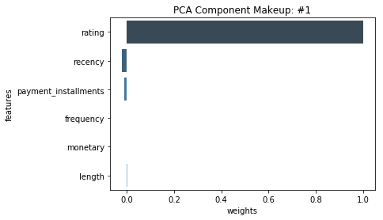

```python
component_num=1

first_comp = v_3[3-component_num]
comps = pd.DataFrame(list(zip(first_comp, t.columns)), columns=['weights', 'features'])
comps['abs_weights']=comps['weights'].apply(lambda x: np.abs(x))
ax=sns.barplot(data=comps.sort_values('abs_weights', ascending=False).head(10), x="weights", y="features", palette="Blues_d")
ax.set_title("PCA Component Makeup: #" + str(component_num))
plt.show()
```

```python
PCA_list=['comp_1', 'comp_2', 'comp_3']
```

### c. Deploying the PCA model

```python
%%time
pca_predictor = pca_SM.deploy(initial_instance_count=1,
                                 instance_type='ml.m5.xlarge')
```

```
-------------!CPU times: user 198 ms, sys: 14.2 ms, total: 212 ms
Wall time: 6min 31s
```

```python
%%time
result = pca_predictor.predict(train_data)
t_transformed=pd.DataFrame()
for a in result:
    b=a.label['projection'].float32_tensor.values
    t_transformed=t_transformed.append([list(b)])
```

```
CPU times: user 2min 16s, sys: 169 ms, total: 2min 17s
Wall time: 2min 18s
```

```python
t_transformed.head()
```

|  | 0 | 1 | 2 | 3 |
| --- | --- | --- | --- | --- |
| 0 | 0.009497 | -0.220507 | -0.161890 | 0.228529 |
| 0 | 0.005807 | 0.074269 | -0.173227 | -0.017639 |
| 0 | 0.001684 | -0.193799 | 0.411981 | -0.283628 |
| 0 | 0.003806 | -0.040677 | 0.115172 | -0.025267 |
| 0 | 0.005365 | -0.129066 | 0.078151 | 0.224492 |

```python
t_transformed.describe()
```

|  | 0 | 1 | 2 | 3 |
| --- | --- | --- | --- | --- |
| count | 9.408700e+04 | 9.408700e+04 | 9.408700e+04 | 9.408700e+04 |
| mean | -3.378040e-09 | 4.932633e-09 | 9.515730e-09 | -6.932832e-08 |
| std | 3.964355e-02 | 1.116954e-01 | 2.104148e-01 | 3.342889e-01 |
| min | -9.931604e-01 | -8.844243e-01 | -3.478676e-01 | -7.892605e-01 |
| 25% | 2.054968e-03 | -4.468829e-02 | -1.691032e-01 | -2.916238e-02 |
| 50% | 4.316702e-03 | 4.854888e-02 | -2.763909e-02 | 2.215428e-01 |
| 75% | 6.334553e-03 | 7.812182e-02 | 1.505494e-01 | 2.292023e-01 |
| max | 1.730619e-02 | 1.133733e-01 | 6.506645e-01 | 2.365779e-01 |

```python
t_transformed.index=t.index
t_transformed=t_transformed.iloc[:,1:]
t_transformed.columns=PCA_list
```

```python
t_transformed.head()
```

|  | comp_1 | comp_2 | comp_3 |
| --- | --- | --- | --- |
| 0 | -0.220507 | -0.161890 | 0.228529 |
| 1 | 0.074269 | -0.173227 | -0.017639 |
| 2 | -0.193799 | 0.411981 | -0.283628 |
| 3 | -0.040677 | 0.115172 | -0.025267 |
| 4 | -0.129066 | 0.078151 | 0.224492 |

## 3). Population segmentation using unsupervised clustering

```python
train_data = t_transformed.values.astype('float32')
```

```python
from sagemaker import KMeans

num_clusters = 6
kmeans = KMeans(role=iam_role,
                train_instance_count=1,
                train_instance_type='ml.m5.xlarge',
                output_path='s3://'+ bucket +'/ecommerce/',
                k=num_clusters)
```

```python
%%time
kmeans.fit(kmeans.record_set(train_data))
```

[output not shown]

[output cut: 15 more lines]

[output not shown]

```python
%%time
kmeans_predictor = kmeans.deploy(initial_instance_count=1,
                                 instance_type='ml.m5.xlarge')
```

```
-------------!CPU times: user 193 ms, sys: 8.36 ms, total: 201 ms
Wall time: 6min 32s
```

```python
%%time
result=kmeans_predictor.predict(train_data)
```

```
CPU times: user 4.2 s, sys: 76 ms, total: 4.28 s
Wall time: 6.54 s
```

```python
cluster_labels = [r.label['closest_cluster'].float32_tensor.values[0] for r in result]
pd.DataFrame(cluster_labels)[0].value_counts()
```

```
2.0    22087
4.0    19700
0.0    17151
5.0    13639
3.0    10830
1.0    10680
Name: 0, dtype: int64
```

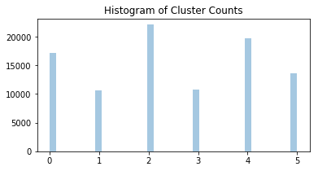

```python
ax=plt.subplots(figsize=(6,3))
ax=sns.distplot(cluster_labels, kde=False)
title="Histogram of Cluster Counts"
ax.set_title(title, fontsize=12)
plt.show()
```

## 4). Drawing conclusions from our modelling

```python
job_name='kmeans-2020-03-18-04-56-39-736'
model_key = "ecommerce/" + job_name + "/output/model.tar.gz"

boto3.resource('s3').Bucket(bucket).download_file(model_key, 'model.tar.gz')
os.system('tar -zxvf model.tar.gz')
os.system('unzip model_algo-1')
Kmeans_model_params = mx.ndarray.load('model_algo-1')
```

```
0
```

```
2304
```

```python
cluster_centroids=pd.DataFrame(Kmeans_model_params[0].asnumpy())
cluster_centroids.columns=t_transformed.columns
cluster_centroids
```

|  | comp_1 | comp_2 | comp_3 |
| --- | --- | --- | --- |
| 0 | -0.010954 | 0.303614 | 0.153429 |
| 1 | 0.006762 | 0.004005 | -0.316754 |
| 2 | -0.006159 | -0.209405 | 0.228370 |
| 3 | -0.005506 | -0.009371 | -0.744297 |
| 4 | 0.012250 | 0.035446 | 0.226471 |
| 5 | 0.005548 | -0.090054 | -0.013084 |

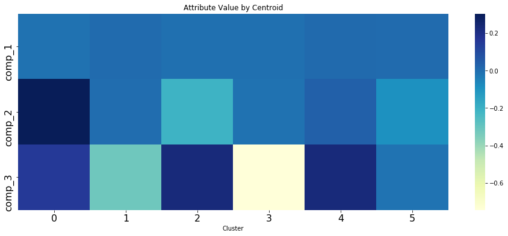

```python
plt.figure(figsize = (16, 6))
ax = sns.heatmap(cluster_centroids.T, cmap = 'YlGnBu')
ax.set_xlabel("Cluster")
plt.yticks(fontsize = 16)
plt.xticks(fontsize = 16)
ax.set_title("Attribute Value by Centroid")
plt.show()
```

```python
t_transformed['labels']=list(map(int, cluster_labels))
t_transformed.head()
```

|  | comp_1 | comp_2 | comp_3 | labels |
| --- | --- | --- | --- | --- |
| 0 | -0.220507 | -0.161890 | 0.228529 | 2 |
| 1 | 0.074269 | -0.173227 | -0.017639 | 5 |
| 2 | -0.193799 | 0.411981 | -0.283628 | 1 |
| 3 | -0.040677 | 0.115172 | -0.025267 | 5 |
| 4 | -0.129066 | 0.078151 | 0.224492 | 4 |

```python
cluster=t_transformed[t_transformed['labels']==1]
cluster.head(5)
```

|  | comp_1 | comp_2 | comp_3 | labels |
| --- | --- | --- | --- | --- |
| 2 | -0.193799 | 0.411981 | -0.283628 | 1 |
| 10 | 0.049753 | 0.224939 | -0.276582 | 1 |
| 18 | -0.032515 | 0.181280 | -0.526799 | 1 |
| 19 | 0.074672 | -0.245846 | -0.266196 | 1 |
| 27 | -0.279806 | 0.353113 | -0.283451 | 1 |

```python
t_transformed.describe()
```

|  | comp_1 | comp_2 | comp_3 | labels |
| --- | --- | --- | --- | --- |
| count | 9.408700e+04 | 9.408700e+04 | 9.408700e+04 | 94087.000000 |
| mean | 4.932633e-09 | 9.515730e-09 | -6.932832e-08 | 2.490663 |
| std | 1.116954e-01 | 2.104148e-01 | 3.342889e-01 | 1.690926 |
| min | -8.844243e-01 | -3.478676e-01 | -7.892605e-01 | 0.000000 |
| 25% | -4.468829e-02 | -1.691032e-01 | -2.916238e-02 | 1.000000 |
| 50% | 4.854888e-02 | -2.763909e-02 | 2.215428e-01 | 2.000000 |
| 75% | 7.812182e-02 | 1.505494e-01 | 2.292023e-01 | 4.000000 |
| max | 1.133733e-01 | 6.506645e-01 | 2.365779e-01 | 5.000000 |

```python
from io import StringIO # python3; python2: BytesIO

csv_buffer = StringIO()
t_transformed.to_csv(csv_buffer,index=False)
s3_resource = boto3.resource('s3')
s3_resource.Object(bucket, key = 'ecommerce/t_transformed.csv').put(Body=csv_buffer.getvalue())
```

```
{'ResponseMetadata': {'RequestId': '72299B3D768C7C1E',
  'HostId': 'e5wG4JyudnYEEUA4yiaGevhOBPISLPEU1l7/HtVVxeOu3jelEql455A6Ke/p13KUjca+4lE9rIA=',
  'HTTPStatusCode': 200,
  'HTTPHeaders': {'x-amz-id-2': 'e5wG4JyudnYEEUA4yiaGevhOBPISLPEU1l7/HtVVxeOu3jelEql455A6Ke/p13KUjca+4lE9rIA=',
   'x-amz-request-id': '72299B3D768C7C1E',
   'date': 'Wed, 18 Mar 2020 05:21:07 GMT',
   'etag': '"955b232c18ef29fc59ddd8467293ebf5"',
   'content-length': '0',
   'server': 'AmazonS3'},
  'RetryAttempts': 0},
 'ETag': '"955b232c18ef29fc59ddd8467293ebf5"'}
```

```python
sagemaker.Session().delete_endpoint(pca_predictor.endpoint)
sagemaker.Session().delete_endpoint(kmeans_predictor.endpoint)
```

## 5). Visualize the cluster

```python
tt_transformed =  pd.read_csv("s3://{}/{}/t_transformed.csv".format(bucket,prefix))
```

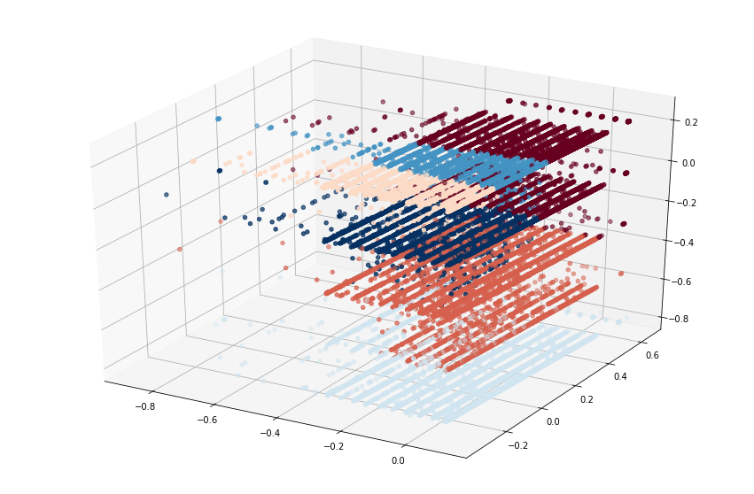

```python
import matplotlib.pyplot as plt
from mpl_toolkits.mplot3d import Axes3D
import pandas as pd
import numpy as np

fig = plt.figure(figsize=(15,10))
ax =plt.axes(projection='3d')
x = np.array(tt_transformed['comp_1'])
y = np.array(tt_transformed['comp_2'])
z = np.array(tt_transformed['comp_3'])

ax.scatter3D(x,y,z, c=tt_transformed['labels'], cmap="RdBu")

plt.show()
```